**Q23.13**

```r
kidney = read.csv("/Users/fangh/academic/cpp/kidney.csv", header = TRUE, sep = ',')
kidney = kidney[ , -c(1:2)]
head(kidney)
```

```
##   Days Duration Weight X.2
## 1    0        1      1   1
## 2    2        1      1   2
## 3    1        1      1   3
## 4    3        1      1   4
## 5    0        1      1   5
## 6    2        1      1   6
```

```r
kidney$Duration = factor(kidney$Duration, levels = c(1, 2), labels = c('short', 'long'))
kidney$Weight = factor(kidney$Weight, levels = c(1, 2, 3), labels = c('mild', 'moderate', 'substantial'))
kidney$Days = log(kidney$Days + 1)/log(10)
kidney_new = kidney[!(kidney$Duration == "long" & kidney$Weight == "mild"), ]
kidney_new$XAij1 = rep(-1, nrow(kidney_new))
kidney_new$XAij1[kidney_new$Duration == "short"] = 1
kidney_new$XBij1 = rep(0, nrow(kidney_new))
kidney_new$XBij1[kidney_new$Weight == "mild"] = 1
kidney_new$XBij1[kidney_new$Weight == "substantial"] = -1
kidney_new$XBij2 = rep(0, nrow(kidney_new))
kidney_new$XBij2[kidney_new$Weight == "moderate"] = 1
kidney_new$XBij2[kidney_new$Weight == "substantial"] = -1
```

**a.**  
Full regression model:  
$Y_{ij} = \mu + \alpha_{1}X^A_{ij1} + \beta_{1}X^B_{ij1} + \beta_{2}X^B_{ij2} + \epsilon_{ij}$  
where $X^A_{ij1}$ equals 1 when i = 1, equals -1 when Duration is i = 2; $X^B_{ij1}$ equals 1 when j = 1, equals 0 when j = 2, equals -1 when j = 3; $X^B_{ij2}$ equals 0 j = 1, equals 1 when j = 2, equals -1 when j = 3;

Reduced model to test factor A’s main effect:  
$Y_{ij} = \mu + \beta_{1}X^B_{ij1} + \beta_{2}X^B_{ij2} + \epsilon_{ij}$, the definition of $X^B$ is just the same as the full model.

Reduced model to test factor B’s main effect:  
$Y_{ij} = \mu + \alpha_{1}X^A_{ij1} + \epsilon_{ij}$, the definiation of $X^A$ is just the same as the full model.

```r
kidney_new2 = kidney_new[,c(1, 5, 6, 7)]
#Full model
fit_full = lm(Days ~ ., data = kidney_new2)
fit_full
```

```
##
## Call:
## lm(formula = Days ~ ., data = kidney_new2)
##
## Coefficients:
## (Intercept)        XAij1        XBij1        XBij2
##     0.66939      0.11733     -0.34323      0.02608
```

```r
#Reduced for A
fit_A = lm(Days ~ .-XAij1, data = kidney_new2)
fit_A
```

```
##
## Call:
## lm(formula = Days ~ . - XAij1, data = kidney_new2)
##
## Coefficients:
## (Intercept)        XBij1        XBij2
##     0.70850     -0.26502     -0.01303
```

```r
#Reduced for B
fit_B = lm(Days ~ XAij1, data = kidney_new2)
fit_B
```

```
##
## Call:
## lm(formula = Days ~ XAij1, data = kidney_new2)
##
## Coefficients:
## (Intercept)        XAij1
##     0.75520      0.03152
```

For full model:  
$Y_{ij} = 0.66939 + 0.11733X^A_{ij1} - 0.34323X^B_{ij1} + 0.02608X^B_{ij2}$  
Reduced model for testing A’s main effect:  
$Y_{ij} = 0.70850 - 0.26502X^B_{ij1} - 0.01303X^B_{ij2}$  
Reduced model for testing B’s main effect:  
$Y_{ij} = 0.75520 + 0.03152X^A_{ij1}$

**b.**

```r
summary(fit_full)
```

```
##
## Call:
## lm(formula = Days ~ ., data = kidney_new2)
##
## Residuals:
##      Min       1Q   Median       3Q      Max
## -0.57814 -0.20825  0.02878  0.26140  0.51076
##
## Coefficients:
##             Estimate Std. Error t value Pr(>|t|)
## (Intercept)  0.66939    0.04940  13.551  < 2e-16 ***
## XAij1        0.11733    0.04940   2.375 0.021766 *
## XBij1       -0.34323    0.08067  -4.255 0.000102 ***
## XBij2        0.02608    0.06377   0.409 0.684511
## ---
## Signif. codes:  0 '***' 0.001 '**' 0.01 '*' 0.05 '.' 0.1 ' ' 1
##
## Residual standard error: 0.3124 on 46 degrees of freedom
## Multiple R-squared:  0.3722, Adjusted R-squared:  0.3313
## F-statistic: 9.091 on 3 and 46 DF,  p-value: 7.758e-05
```

```r
summary(aov(Days ~ Weight + Duration, data = kidney_new))
```

```
##             Df Sum Sq Mean Sq F value   Pr(>F)
## Weight       2  2.111  1.0557  10.817 0.000141 ***
## Duration     1  0.551  0.5506   5.641 0.021766 *
## Residuals   46  4.490  0.0976
## ---
## Signif. codes:  0 '***' 0.001 '**' 0.01 '*' 0.05 '.' 0.1 ' ' 1
```

For factor Weight:  
$H_0: beta_i = 0~ vs.~ H_a: exist~ beta_i \neq 0$  
$F^*$ = ((SSE(A) - SSE(A, B))/(df(R) - df(F)))/(SSE(A, B)/df(F)) = 1.3072/0.0976 = 13.393  
if $F^*$ > F(0.95, 2, 46), we conclude $H_a$, otherwise we conclude $H_0$  
$F^*$ = 13.393 > F(0.95, 2, 46) = 3.200, so we conclude $H_a$, the main effect of Weight is significant.  
The P-value is 2.61e-05

**Q23.19**

```r
element = c(0.73, 0.86, 0.94, 1.40, 1.62, 0.67, 0.75, 0.81, 1.32, 1.41, 0.15, 0.21, 0.26, 0.75, 0.78)
block = rep(1:5, 3)
fat = rep(1:3, each = 5)
data = as.data.frame(cbind(block, fat, element))
data$block = as.factor(data$block)
data$fat = as.factor(data$fat)
data2 = data[!(data$block == 1 & data$fat == 3) & !(data$block == 5 & data$fat == 1), ]
```

The ANOVA model is:  
$Y_{ij} = \mu + \rho_{i} + \tau_{j} + \epsilon_{ij}$

The equivalent regression model:  
$Y_{ij} = \mu + \rho_{1}X^A_{ij1} + \rho_{2}X^A_{ij2} + ... + \rho_{4}X^A_{ij4} + \tau_{1}X^B_{ij1} + \tau_{2}X^B_{ij2} + \epsilon_{ij}$  
where $X^A_{ijk} = -1$ when i = 5, $X^A_{ijk}$ = 1 when i = k, otherwise $X^A_{ijk}$ = 0; $X^B_{ijk}$ = -1 when j = 3, $X^B_{ijk}$ = 1 when j = k, otherwise $X^B_{ijk}$ = 0.

```r
names_A = paste0("XAij", as.character(c(1:4)))
names_B = paste0("XBij", as.character(c(1:2)))
data2[, names_A] = rep(0, nrow(data2))
data2[, names_B] = rep(0, nrow(data2))
for(i in 1:4){
  data2[, names_A[i]][data2$block == i] = 1
  data2[, names_A[i]][data2$block == 5] = -1
}
for(i in 1:2){
  data2[, names_B[i]][data2$fat == i] = 1
  data2[, names_B[i]][data2$fat == 3] = -1
}
data_new = data2[, -c(1, 2)]
fit = lm(element ~ ., data = data_new)
fit
```

```
##
## Call:
## lm(formula = element ~ ., data = data_new)
##
## Coefficients:
## (Intercept)        XAij1        XAij2        XAij3        XAij4
##      0.8294      -0.3361      -0.2227      -0.1594       0.3273
##       XBij1        XBij2
##      0.2508       0.1626
```

The Full model:  
$Y_{ij} = 0.8294 - 0.3361X^A_{ij1} - 0.2227X^A_{ij2} - 0.1594X^A_{ij3} + 0.3273X^A_{ij4} + 0.2508X^B_{ij1} + 0.1626X^B_{ij2}$

**b.**  
The reduced model:  
$Y_{ij} = \mu + \rho_{1}X^A_{ij1} + \rho_{2}X^A_{ij2} + ... + \rho_{4}X^A_{ij4} + \epsilon_{ij}$  
The definition of $X^A_{ijk}$ is just the same as the full model.

```r
fit_r = lm(element ~ ., data = data_new[, c(1:(ncol(data_new) - 2))])
fit_r
```

```
##
## Call:
## lm(formula = element ~ ., data = data_new[, c(1:(ncol(data_new) -
##     2))])
##
## Coefficients:
## (Intercept)        XAij1        XAij2        XAij3        XAij4
##      0.8457      -0.1457      -0.2390      -0.1757       0.3110
```

$Y_{ij} = 0.8457 - 0.1457X^A_{ij1} - 0.2390X^A_{ij2} - 0.1757X^A_{ij3} + 0.3110X^A_{ij3}$

**c.**

```r
anova(fit)
```

```
## Analysis of Variance Table
##
## Response: element
##           Df  Sum Sq Mean Sq  F value    Pr(>F)
## XAij1      1 0.15603 0.15603  267.027 3.344e-06 ***
## XAij2      1 0.16835 0.16835  288.129 2.673e-06 ***
## XAij3      1 0.05024 0.05024   85.975 8.896e-05 ***
## XAij4      1 0.34543 0.34543  591.186 3.181e-07 ***
## XBij1      1 0.77223 0.77223 1321.629 2.889e-08 ***
## XBij2      1 0.17845 0.17845  305.399 2.252e-06 ***
## Residuals  6 0.00351 0.00058
## ---
## Signif. codes:  0 '***' 0.001 '**' 0.01 '*' 0.05 '.' 0.1 ' ' 1
```

```r
#With
summary(aov(element ~ block + fat , data = data2))
```

```
##             Df Sum Sq Mean Sq F value   Pr(>F)
## block        4 0.7200  0.1800   308.1 4.53e-07 ***
## fat          2 0.9507  0.4753   813.5 4.96e-08 ***
## Residuals    6 0.0035  0.0006
## ---
## Signif. codes:  0 '***' 0.001 '**' 0.01 '*' 0.05 '.' 0.1 ' ' 1
```

```r
#With no missing observation
summary(aov(element ~ block + fat, data = data))
```

```
##             Df Sum Sq Mean Sq F value   Pr(>F)
## block        4 1.4190  0.3547   146.9 1.61e-07 ***
## fat          2 1.3203  0.6601   273.4 4.33e-08 ***
## Residuals    8 0.0193  0.0024
## ---
## Signif. codes:  0 '***' 0.001 '**' 0.01 '*' 0.05 '.' 0.1 ' ' 1
```

**d.**

```r
summary(fit)
```

```
##
## Call:
## lm(formula = element ~ ., data = data_new)
##
## Residuals:
##       Min        1Q    Median        3Q       Max
## -0.026984 -0.014127  0.002487  0.014127  0.026984
##
## Coefficients:
##              Estimate Std. Error t value Pr(>|t|)
## (Intercept)  0.829407   0.006900  120.20 2.24e-11 ***
## XAij1       -0.336127   0.015648  -21.48 6.64e-07 ***
## XAij2       -0.222741   0.012825  -17.37 2.34e-06 ***
## XAij3       -0.159407   0.012825  -12.43 1.66e-05 ***
## XAij4        0.327259   0.012825   25.52 2.39e-07 ***
## XBij1        0.250847   0.010252   24.47 3.07e-07 ***
## XBij2        0.162593   0.009304   17.48 2.25e-06 ***
## ---
## Signif. codes:  0 '***' 0.001 '**' 0.01 '*' 0.05 '.' 0.1 ' ' 1
##
## Residual standard error: 0.02417 on 6 degrees of freedom
## Multiple R-squared:  0.9979, Adjusted R-squared:  0.9958
## F-statistic: 476.6 on 6 and 6 DF,  p-value: 9.153e-08
```

```r
mse_root = 0.02417
X = as.matrix(data_new[, -1])
#Covariance matrix
cov_co = solve(t(X) %*% X) * mse_root^2
```

$\hat{L} = \hat{\tau}_1 - \hat{\tau}_{3} = 2\hat{\tau}_1 + \hat{\tau}_2 = 0.664287$  
The Covariance matrix is:

```r
cov_co
```

```
##               XAij1         XAij2         XAij3         XAij4
## XAij1  2.412624e-04 -4.956754e-05 -4.956754e-05 -4.956754e-05
## XAij2 -4.956754e-05  1.628648e-04 -3.186485e-05 -3.186485e-05
## XAij3 -4.956754e-05 -3.186485e-05  1.628648e-04 -3.186485e-05
## XAij4 -4.956754e-05 -3.186485e-05 -3.186485e-05  1.628648e-04
## XBij1 -3.641697e-05 -3.540539e-06 -3.540539e-06 -3.540539e-06
## XBij2 -1.062162e-05  7.081078e-06  7.081078e-06  7.081078e-06
##               XBij1         XBij2
## XAij1 -3.641697e-05 -1.062162e-05
## XAij2 -3.540539e-06  7.081078e-06
## XAij3 -3.540539e-06  7.081078e-06
## XAij4 -3.540539e-06  7.081078e-06
## XBij1  1.046988e-04 -4.248647e-05
## XBij2 -4.248647e-05  8.497293e-05
```

```r
c = matrix(c(0, 0, 0, 0, 2, 1))
t(c) %*% cov_co %*% c
```

```
##              [,1]
## [1,] 0.0003338222
```

$s^2(\hat{L}) = t(c) \%*\% cov\_co \%*\% c = 0.0003338222$  
so $s(\hat{L}) = 0.0182708$  
L = 0.664287 - qt(0.99, 6) * 0.0182708 = 0.6068679  
U = 0.664287 + qt(0.99, 6) * 0.0182708 = 0.7217061  
So our confidence interval for $\hat{L}$ is (0.6068679, 0.7217061)

**Q24.12**  
Residuals:

```r
data = read.csv("~/hw3.csv", header = TRUE)
data$A = as.factor(data$A)
data$B = as.factor(data$B)
data$C = as.factor(data$C)
aov_out = aov(Time ~ A*B*C, data = data)
aov_out$residuals
```

```
##     1     2     3     4     5     6     7     8     9    10    11    12
##  31.4 -43.6  17.4  20.4 -25.6 -30.0  48.0  18.0 -55.0  19.0  44.8 -23.2
##    13    14    15    16    17    18    19    20    21    22    23    24
## -33.2  20.8  -9.2  -3.4 -12.4   0.6 -25.4  40.6  -1.2 -28.2 -17.2  13.8
##    25    26    27    28    29    30    31    32    33    34    35    36
##  32.8 -18.2  15.8   5.8  25.8 -29.2  29.6  39.6 -32.4 -34.4  -2.4  -6.6
##    37    38    39    40    41    42    43    44    45    46    47    48
## -22.6  10.4  21.4  -2.6  27.6 -34.4 -26.4  50.6 -17.4  -4.6  12.4  25.4
##    49    50    51    52    53    54    55    56    57    58    59    60
## -34.6   1.4   0.6  -0.4  14.6 -20.4   5.6 -19.4   4.6 -43.4  50.6   7.6
```

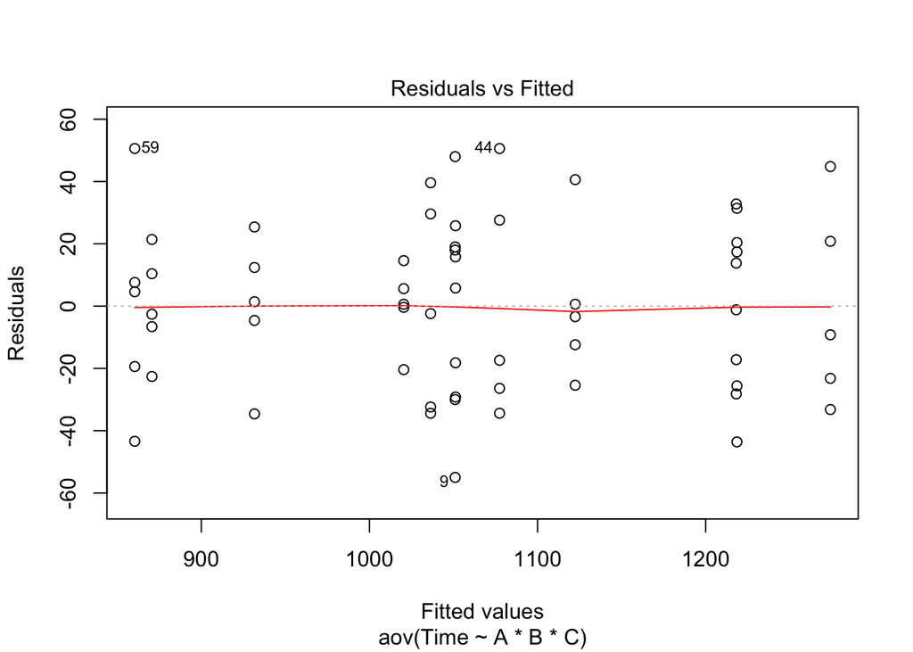

```r
plot(aov_out, which = 1)
```

There is no obvious nonlinear pattern in our residuals vs fitted value plot, so the ANOVA model seems to be approperiate.

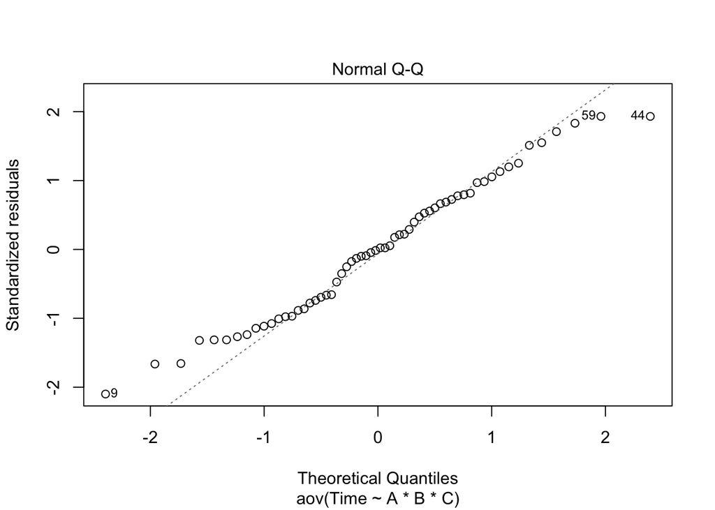

```r
plot(aov_out, which = 2)
```

```r
expvalue = rep(1, 60)
for(i in 1:60)
{
  expvalue[i] = qnorm((i - 0.375)/(60 + 0.25), 0, 1)
}
ordered_res = sort(aov_out$residuals, decreasing = FALSE)
cor(expvalue, ordered_res)
```

```
## [1] 0.9916214
```

The coefficient of correlation between the ordered residuals and their expected value is 0.9916214, which is comparatively high, suggest that the normality assumption is reasonable.